# Hill Climbing as test for causal model

## Quick start (reproducible run)

From the project root:

```bash
Rscript scripts/setup_renv.R
Rscript scripts/run_all.R
```

The setup script initializes `renv`, installs required packages, and writes `renv.lock`. The run script restores package versions from `renv.lock` and renders `README.Rmd`.

We apply causal inference techniques, expert-elicited probabilities, and optimization algorithms, to improve decision-making for interventions aimed at enhancing livelihoods through agroforestry. We use a hill-climbing algorithm to learn the structure of a Bayesian Network (BN) based on observed data. The observed data contains information from publications, each contributing to various factors that may influence agroforestry systems and livelihoods in different regions. The goal is to use this data to infer the best network structure that best explains the dependencies among the variables in the dataset. See the details in `hill_climbing.R`.

We aim to build a predictive decision model that connects causal relationships between planting trees on farms and farmer livelihoods. The process has three main steps: 1. searching available literature to define the key causal relationships related to planting trees on farms. A Directed Acyclic Graph (DAG) will be constructed to visually represent these relationships, incorporating various factors like costs, benefits, risks, and their impact on livelihoods, 2. the causal model will be translated into a BN. Literature results will be used to fill in the Conditional Probability Tables (CPTs) for each node in the BN, providing the probability distributions based on available data, 3. once the Bayesian Network is constructed, data will be gathered (even if minimal) to test and refine the model. The hill climbing algorithm will be applied to optimize the model’s parameters by adjusting them to best fit the observed data. The optimization process will focus on maximizing the model’s predictive accuracy and identifying the most likely causal relationships. The work demonstrates a robust and adaptable decision model.

```r
  source("functions/dagitty_tree_planting.R")
```

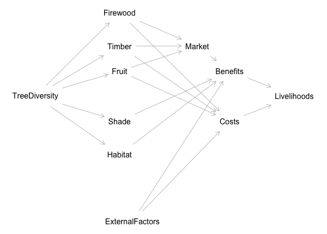

```r
# Plot the DAG
plot(dag)
```

We build the same graph in `bnlearn` for use in that environment. See all the custom CPTs in `model_in_bnlearn.R`.

```r
source("functions/model_in_bnlearn.R")
```

```
#>
#> Probability of improved livelihoods given high tree diversity:  0.693154
```

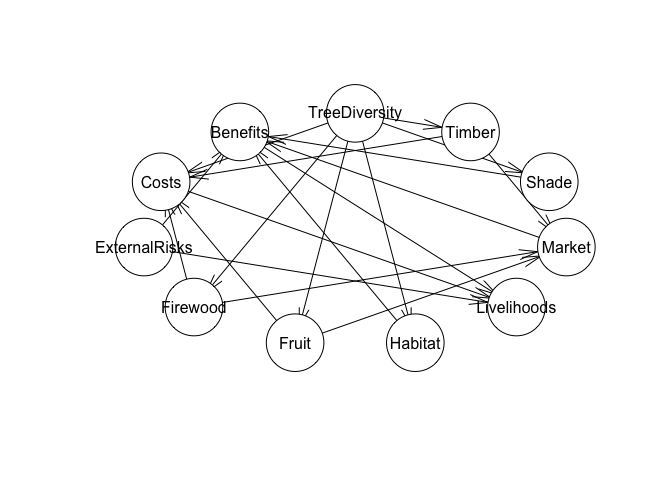

```r
plot(network_structure)
```

## Perform inference

Calculate the probability of “Livelihoods” being “Improved” given high tree diversity.

```r
cpquery(bn_fitted, event = (Livelihoods == "Improved"), evidence = (TreeDiversity == "High"))
```

```
#> [1] 0.6934928
```

To validate our Bayesian Network, we can perform several tests to ensure that the model behaves as expected and that the conditional dependencies between the nodes are correctly represented.

### Test for inconsistent Evidence

Here we introduce evidence that contradicts the dependency structure to check for the system response. A node conditioned on one state `TreeDiversity == "Low"`, but the evidence `Firewood == "Yes"` conflicts with `bn_fitted`, it should return a very low or zero probability (for each iteration of the model).

```r
cpquery(bn_fitted, event = (TreeDiversity == "Low"), evidence = (Firewood == "Yes"))
```

```
#> [1] 0.01380104
```

### Query for Node Probabilities

Example for Livelihoods:

```r
cpquery(bn_fitted, event = (Livelihoods == "Improved"), evidence = (Benefits == "High"))
```

```
#> [1] 0.7348718
```

### Sensitivity Analysis

Perform a sensitivity analysis to understand how changes in one or more variables affect the results. For example, change the probability of Firewood or Timber and see how it affects the probability of Livelihoods.

```r
cpquery(bn_fitted, event = (Livelihoods == "Improved"), evidence = (Timber == "Yes"))
```

```
#> [1] 0.6721055
```

### Simulation and Comparison with Expected Results

Generate synthetic data based on the network structure and compare it with expected or known results.

```r
# Simulate 1000 samples
simulated_data <- rbn(bn_fitted, n = 1000)
head(simulated_data)
```

```
#>   Benefits Costs ExternalRisks Firewood Fruit Habitat  Livelihoods Market Shade
#> 1     High  High           Low       No   Yes     Yes     Improved   High   Yes
#> 2     High   Low           Low      Yes   Yes     Yes     Improved   High   Yes
#> 3     High   Low          High      Yes   Yes     Yes     Improved   High   Yes
#> 4      Low   Low          High       No    No      No Not Improved    Low    No
#> 5     High  High          High      Yes   Yes     Yes Not Improved   High    No
#> 6      Low   Low          High       No    No      No     Improved    Low   Yes
#>   Timber TreeDiversity
#> 1    Yes          High
#> 2     No          High
#> 3    Yes          High
#> 4    Yes           Low
#> 5    Yes          High
#> 6    Yes           Low
```

Calculate the observed distribution of ‘Livelihoods.’

```r
observed_Livelihoods <- table(simulated_data$Livelihoods) / nrow(simulated_data)

observed_Livelihoods
```

```
#>
#>     Improved Not Improved
#>        0.689        0.311
```

Save the expectation for ‘Livelihoods.’

```r
expected_Livelihoods <- c("Improved" = 0.7, "Not Improved" = 0.3)
```

Compare the observed distribution with the expected one.

```r
data.frame(
  "Observed" = observed_Livelihoods,
  "Expected" = expected_Livelihoods
)
```

```
#>              Observed.Var1 Observed.Freq Expected
#> Improved          Improved         0.689      0.7
#> Not Improved  Not Improved         0.311      0.3
```

Calculate the distribution of ‘Timber’ given ‘TreeDiversity’ (example for other node relationships too).

```r
table(simulated_data$Timber, simulated_data$TreeDiversity) / nrow(simulated_data)
```

```
#>
#>        High   Low
#>   Yes 0.394 0.494
#>   No  0.106 0.006
```

Visualize Livelihoods results.

[figure not shown]

```r
library(ggplot2)

ggplot(simulated_data, aes(x = Livelihoods)) +
  geom_bar(aes(y = after_stat(prop)), stat = "count") +
  scale_y_continuous(labels = scales::percent) +
  ggtitle("Distribution of Livelihoods in Simulated Data")
```

### Hill-climbing algorithm

Learn the structure of a Bayesian network using a hill-climbing algorithm `hc`.

The observations for the are based on reports from the literature:

Agroforestry introduces both initial and ongoing costs, including planting, labor, and pruning, which can constrain adoption, particularly for resource-poor farmers. External factors, such as market access, extension services, and credit availability, significantly influence these costs, as demonstrated in studies on farmer-managed natural regeneration in Niger (Haglund et al. (2011)) and agroforestry practices in sloping lands of Asia and the Pacific (Craswell et al. (1997)). Bureaucratic inefficiencies and limited market alternatives also add to these challenges (Akter et al. (2022)).

Despite the costs, agroforestry provides substantial benefits to farmers. It enhances access to food, timber, fuelwood, and fodder, directly improving livelihood capitals, as observed in tropical moist forests in Bangladesh (Akter et al. (2022)). Agroforestry supports biodiversity conservation, soil fertility, and carbon sequestration, making it a key strategy for climate change mitigation and adaptation in Sub-Saharan Africa (Verchot et al. (2007); Bogale and Bekele (2023)). In Ethiopia, smallholder farmers benefit from improved productivity and diversified income streams through agroforestry (Amare et al. (2019)), while in Kenya, agroforestry can increase household food security, particularly in regions prone to wildlife crop raiding (Quandt (2021)). Agroforestry systems also provide resilience to environmental stressors by diversifying income sources and creating favorable microclimates (Ngango et al. (2024); Bishaw (2013)).

However, farmers can also face challenges such as reduced crop yields due to competition for water, nutrients, and light, as well as exposure to fluctuating market conditions (Do et al. (2024); Akter et al. (2022)). These risks are compounded by adoption barriers, including insecure land tenure and lack of institutional support (Hughes et al. (2020); Johansson, Axelsson, and Kimanzu (2013)).

The interplay of costs, benefits, and risks ultimately determines the impact of agroforestry on livelihoods. While high costs and risks can hinder adoption and sustainability, the benefits—such as increased resilience, economic returns, and ecosystem services—can offset these challenges (Quandt (2021); Awazi and Avana-Tientcheu (2020)). External factors like cooperative memberships and extension services significantly shape the outcomes of agroforestry systems (Ngango et al. (2024); Bishaw (2013)). Research in Bangladesh highlights agroforestry’s positive impacts on livelihoods despite systemic inefficiencies (Akter et al. (2022)), while studies in Ethiopia and Kenya demonstrate agroforestry’s role in reducing livelihood risks and enhancing resilience to environmental stress (Amare et al. (2019); Bishaw (2013)). In Cameroon, agroforestry has been shown to mitigate conflict between farmers and pastoralists, promoting social and economic stability (Awazi and Avana-Tientcheu (2020)). Similarly, agroforestry practices in Tanzania reveal that social and ecological factors, such as tree survival rates and community perceptions, influence the sustainability of these systems (Johansson, Axelsson, and Kimanzu (2013)).

Agroforestry’s potential to address multiple livelihood and environmental challenges is clear, but its success depends on targeted policy interventions to reduce costs, mitigate risks, and enhance benefits, ensuring equitable access and scalability across diverse contexts.

```r
# Example with hill climbing (using bnlearn)
library(bnlearn)
```

We used the score-based structure learning algorithm from `bnlearn` to learn the structure of a Bayesian network using a hill-climbing algorithm. We used the observed data from the publications with some missing values (NA) for unobserved nodes.

```r
source("data/observed_data.R")
```

Convert all the character columns from our observations into factors for the hill climbing.

```r
# Convert character columns to factors
observed_data$TreeDiversity <- as.factor(observed_data$TreeDiversity)
observed_data$Timber <- as.factor(observed_data$Timber)
observed_data$Firewood <- as.factor(observed_data$Firewood)
observed_data$Fruit <- as.factor(observed_data$Fruit)
observed_data$Market <- as.factor(observed_data$Market)
observed_data$Shade <- as.factor(observed_data$Shade)
observed_data$Habitat <- as.factor(observed_data$Habitat)
observed_data$ExternalRisks <- as.factor(observed_data$ExternalRisks)
observed_data$Costs <- as.factor(observed_data$Costs)
observed_data$Benefits <- as.factor(observed_data$Benefits)
observed_data$Livelihoods <- as.factor(observed_data$Livelihoods)
```

Plot the fitted model with the data from the papers only.

```r
source("functions/model_in_bnlearn.R")
```

```
#> Probability of improved livelihoods given high tree diversity:  0.6926124
```

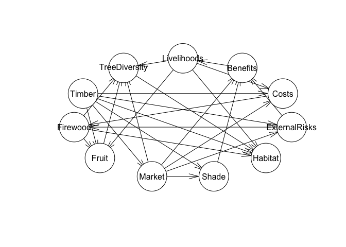

```r
# x in hc = the observations alone
fitted_model <- hc(observed_data)
plot(fitted_model)
```

Plot the model based on both our model structure and the literature when we use the original network structure as a `start`. This is a `class bn` object. It shows DAG and we use it to initialize the `hc` algorithm.

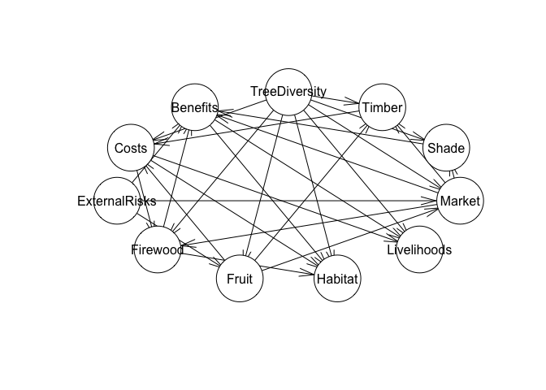

```r
# x in hc = the observations
# start = the original network structure
hill_climbing_model <- hc(x= observed_data, start = network_structure)
plot(hill_climbing_model)
```

# References

Akter, Rojina, Mohammad Kamrul Hasan, Khondokar H. Kabir, Dietrich Darr, and Nasima Akter Roshni. 2022. “Agroforestry Systems and Their Impact on Livelihood Improvement of Tribal Farmers in a Tropical Moist Deciduous Forest in Bangladesh.” *Trees, Forests and People* 9 (September): 100315. https://doi.org/10.1016/j.tfp.2022.100315.

Amare, Dagninet, Menale Wondie, Wolde Mekuria, and Dietrich Darr. 2019. “Agroforestry of Smallholder Farmers in Ethiopia: Practices and Benefits.” *Small-Scale Forestry* 18 (1): 39–56. https://doi.org/10.1007/s11842-018-9405-6.

Awazi, Nyong Princely, and Marie-Louise Avana-Tientcheu. 2020. “Agroforestry as a Sustainable Means to Farmer–Grazier Conflict Mitigation in Cameroon.” *Agroforestry Systems* 94 (6): 2147–65. https://doi.org/10.1007/s10457-020-00537-y.

Bishaw, Badege. 2013. *Farmers’ Strategies for Adapting to Mitigating Climate Variability and Change Through Agroforestry in Ethiopia and Kenya*.

Bogale, Girma Asefa, and Solomon Estifanos Bekele. 2023. “Sustainability of Agroforestry Practices and Their Resilience to Climate Change Adaptation and Mitigation in Sub-Saharan Africa: A Review.” *Ekológia (Bratislava)* 42 (2): 179–92. https://doi.org/10.2478/eko-2023-0021.

Craswell, E. T., A. Sajjapongse, D. J. B. Howlett, and A. J. Dowling. 1997. “Agroforestry in the Management of Sloping Lands in Asia and the Pacific.” *Agroforestry Systems* 38 (1): 121–37. https://doi.org/10.1023/A:1005960612386.

Do, Hoa, Cory Whitney, Nguyen La, Hugo Storm, and Eike Luedeling. 2024. “Adapting Agroforestry to Upland Farming Systems: Narratives from Smallholder Farmers in Northwest Vietnam.” *Agronomy for Sustainable Development* 44 (2): 17. https://doi.org/10.1007/s13593-024-00954-8.

Haglund, Eric, Jupiter Ndjeunga, Laura Snook, and Dov Pasternak. 2011. “Dry Land Tree Management for Improved Household Livelihoods: Farmer Managed Natural Regeneration in Niger.” *Journal of Environmental Management* 92 (7): 1696–1705. https://doi.org/10.1016/j.jenvman.2011.01.027.

Hughes, Karl, Seth Morgan, Katherine Baylis, Judith Oduol, Emilie Smith-Dumont, Tor-Gunnar Vågen, and Hilda Kegode. 2020. “Assessing the Downstream Socioeconomic Impacts of Agroforestry in Kenya.” *World Development* 128 (April): 104835. https://doi.org/10.1016/j.worlddev.2019.104835.

Johansson, Karl-Erik, Robert Axelsson, and Ngolia Kimanzu. 2013. “Mapping the Relationship of Inter-Village Variation in Agroforestry Tree Survival with Social and Ecological Characteristics: The Case of the Vi Agroforestry Project, Mara Region, Tanzania.” *Sustainability* 5 (12): 5171–94. https://doi.org/10.3390/su5125171.

Ngango, Jules, Edouard Musabanganji, Aristide Maniriho, Ferdinand Nkikabahizi, Anitha Mukamuhire, and John N. Ng’ombe. 2024. “Does Agroforestry Contribute to Household Food Security? A Micro-Perspective from Southern Rwanda.” *Forest Policy and Economics* 165 (August): 103252. https://doi.org/10.1016/j.forpol.2024.103252.

Quandt, Amy. 2021. “Agroforestry Trees for Improved Food Security on Farms Impacted by Wildlife Crop Raiding in Kenya.” *Trees, Forests and People* 4 (June): 100069. https://doi.org/10.1016/j.tfp.2021.100069.

Verchot, Louis V., Meine Van Noordwijk, Serigne Kandji, Tom Tomich, Chin Ong, Alain Albrecht, Jens Mackensen, Cynthia Bantilan, K. V. Anupama, and Cheryl Palm. 2007. “Climate Change: Linking Adaptation and Mitigation Through Agroforestry.” *Mitigation and Adaptation Strategies for Global Change* 12 (5): 901–18. https://doi.org/10.1007/s11027-007-9105-6.